# Homework 1: Insights on Poverty

February 4, 2016

**This homework is due Sunday February 14, 2016 at 11:59 PM. When complete, submit your code in the R Markdown file and the knitted HTML file on Canvas.**

# Background

This HW is based on Hans Rosling talks [New Insights on Poverty](https://www.ted.com/talks/hans_rosling_reveals_new_insights_on_poverty?language=en) and [The Best Stats You’ve Ever Seen](https://www.ted.com/talks/hans_rosling_shows_the_best_stats_you_ve_ever_seen).

1. Sri Lanka or Turkey
2. Poland or South Korea
3. Malaysia or Russia
4. Pakistan or Vietnam
5. Thailand or South Africa

Most people get them wrong. Why is this? In part it is due to our preconceived notion that the world is divided into two groups: the *Western world* versus the *third world*, characterized by “long life,small family” and “short life, large family” respectively. In this homework we will use data visualization to gain insights on this topic.

# Problem 1

The first step in our analysis is to download and organize the data. The necessary data to answer these question is available on the [gapminder](http://www.gapminder.org/data/) website.

## Problem 1.1

We will use the following datasets:

1. [Childhood mortality](http://spreadsheets.google.com/pub?key=0ArfEDsV3bBwCcGhBd2NOQVZ1eWowNVpSNjl1c3lRSWc&output=csv)
2. [Life expectancy](http://spreadsheets.google.com/pub?key=phAwcNAVuyj2tPLxKvvnNPA&output=csv)
3. [Fertility](http://spreadsheets.google.com/pub?key=phAwcNAVuyj0TAlJeCEzcGQ&output=csv)
4. [Population](http://spreadsheets.google.com/pub?key=phAwcNAVuyj0XOoBL_n5tAQ&output=csv)
5. [Total GDP](http://spreadsheets.google.com/pub?key=pyj6tScZqmEfI4sLVvEQtHw&output=csv)

Create five `tbl_df` table objects, one for each of the tables provided in the above files. Hints: Use the `read_csv` function. Because these are only temporary files, give them short names.

## Problem 1.2

Write a function called `my_func` that takes a table as an argument and returns the column name. For each of the five tables, what is the name of the column containing the country names? Print out the tables or look at them with `View` to determine the column.

```r
# Return the column names in a data frame
my_func <- function(x){
  return (colnames(x))
}
head(my_func(mort))
```

```
## [1] "Under five mortality" "1800"                 "1801"
## [4] "1802"                 "1803"                 "1804"
```

```r
head(my_func(life))
```

```
## [1] "Life expectancy with projections. Yellow is IHME"
## [2] "1800"
## [3] "1801"
## [4] "1802"
## [5] "1803"
## [6] "1804"
```

```r
head(my_func(fert))
```

```
## [1] "Total fertility rate" "1800"                 "1801"
## [4] "1802"                 "1803"                 "1804"
```

```r
head(my_func(pop))
```

```
## [1] "Total population" "1800"             "1810"
## [4] "1820"             "1830"             "1840"
```

```r
head(my_func(gdp))
```

```
## [1] "GDP (constant 2000 US$)" "1960"
## [3] "1961"                    "1962"
## [5] "1963"                    "1964"
```

```r
#Print the name of column i in the table df
my_printfunc <- function(df, i){
  print(paste("Name of the column in", deparse(substitute(df)), "table containing the country name : ", my_func(df)[i]))
}

my_printfunc(mort,1)
```

```
## [1] "Name of the column in mort table containing the country name :  Under five mortality"
```

```r
my_printfunc(life,1)
```

```
## [1] "Name of the column in life table containing the country name :  Life expectancy with projections. Yellow is IHME"
```

```r
my_printfunc(fert,1)
```

```
## [1] "Name of the column in fert table containing the country name :  Total fertility rate"
```

```r
my_printfunc(pop,1)
```

```
## [1] "Name of the column in pop table containing the country name :  Total population"
```

```r
my_printfunc(gdp,1)
```

```
## [1] "Name of the column in gdp table containing the country name :  GDP (constant 2000 US$)"
```

## Problem 1.3

In the previous problem we noted that gapminder is inconsistent in naming their country column. Fix this by assigning a common name to this column in the various tables.

```r
names(mort)[1]<-"country"
names(life)[1]<-"country"
names(fert)[1]<-"country"
names(pop)[1]<-"country"
names(gdp)[1]<-"country"
```

## Problem 1.4

```r
library(tidyr)
```

We call this the *long* format. Use the `gather` function from the `tidyr` package to create a new table for childhood mortality using the long format. Call the new columns `year` and `child_mortality`

```r
mort_long <- gather(mort, key=year, value=child_mortality, -country)
```

Now redefine the remaining tables in this way.

```r
life_long <- gather(life, key=year, value=lifeExp, -country)
fert_long <- gather(fert,key=year, value=fertility, -country)
pop_long <- gather(pop, key=year, value=population, -country)
gdp_long <- gather(gdp, key=year, value=gdp, -country)
```

## Problem 1.5

Now we want to join all these files together. Make one consolidated table containing all the columns

```r
alldata <- full_join(mort_long,life_long, by = c("country", "year")) %>%
           full_join(fert_long, c("country", "year")) %>%
           full_join(pop_long, c("country", "year")) %>%
           full_join(gdp_long, c("country", "year"))
```

## Problem 1.6

Add a column to the consolidated table containing the continent for each country. Hint: We have created a file that maps countries to continents [here](https://github.com/datasciencelabs/data/blob/master/homework_data/continent-info.tsv). Hint: Learn to use the `left_join` function.

```r
filename = "https://raw.githubusercontent.com/datasciencelabs/data/master/homework_data/continent-info.tsv"
continent <- read_tsv(filename, col_names = c("country","continent"))

# join the continent to the alldata table
alldata <-left_join(alldata, continent, by = "country") %>%
mutate(continent=ifelse(is.na(continent)==TRUE,"Unknown",continent))
```

# Problem 2

Report the child mortalilty rate in 2015 for these 5 pairs:

1. Sri Lanka or Turkey
2. Poland or South Korea
3. Malaysia or Russia
4. Pakistan or Vietnam
5. Thailand or South Africa

```r
filter(alldata, country %in% c("Sri Lanka","Turkey") & year==2015) %>% select(country, child_mortality)
```

```
## Source: local data frame [2 x 2]
##
##     country child_mortality
##       (chr)           (dbl)
## 1 Sri Lanka             8.7
## 2    Turkey            13.5
```

```r
filter(alldata, country %in% c("Poland","South Korea") & year==2015) %>% select(country, child_mortality)
```

```
## Source: local data frame [2 x 2]
##
##       country child_mortality
##         (chr)           (dbl)
## 1 South Korea             3.5
## 2      Poland             5.2
```

```r
filter(alldata, country %in% c("Malaysia","Russia") & year==2015) %>% select(country, child_mortality)
```

```
## Source: local data frame [2 x 2]
##
##    country child_mortality
##      (chr)           (dbl)
## 1 Malaysia             8.2
## 2   Russia             9.6
```

```r
filter(alldata, country %in% c("Pakistan","Vietnam") & year==2015) %>% select(country, child_mortality)
```

```
## Source: local data frame [2 x 2]
##
##    country child_mortality
##      (chr)           (dbl)
## 1 Pakistan            81.1
## 2  Vietnam            21.7
```

```r
filter(alldata, country %in% c("Thailand","South Africa") & year==2015) %>% select(country, child_mortality)
```

```
## Source: local data frame [2 x 2]
##
##        country child_mortality
##          (chr)           (dbl)
## 1 South Africa            42.1
## 2     Thailand            12.3
```

# Problem 3

To examine if in fact there was a long-life-in-a-small-family and short-life-in-a-large-family dichotomy, we will visualize the average number of children per family (fertility) and the life expectancy for each country.

## Problem 3.1

Use `ggplot2` to create a plot of life expectancy versus fertilty for 1962 for Africa, Asia, Europe, and the Americas. Use color to denote continent and point size to denote population size:

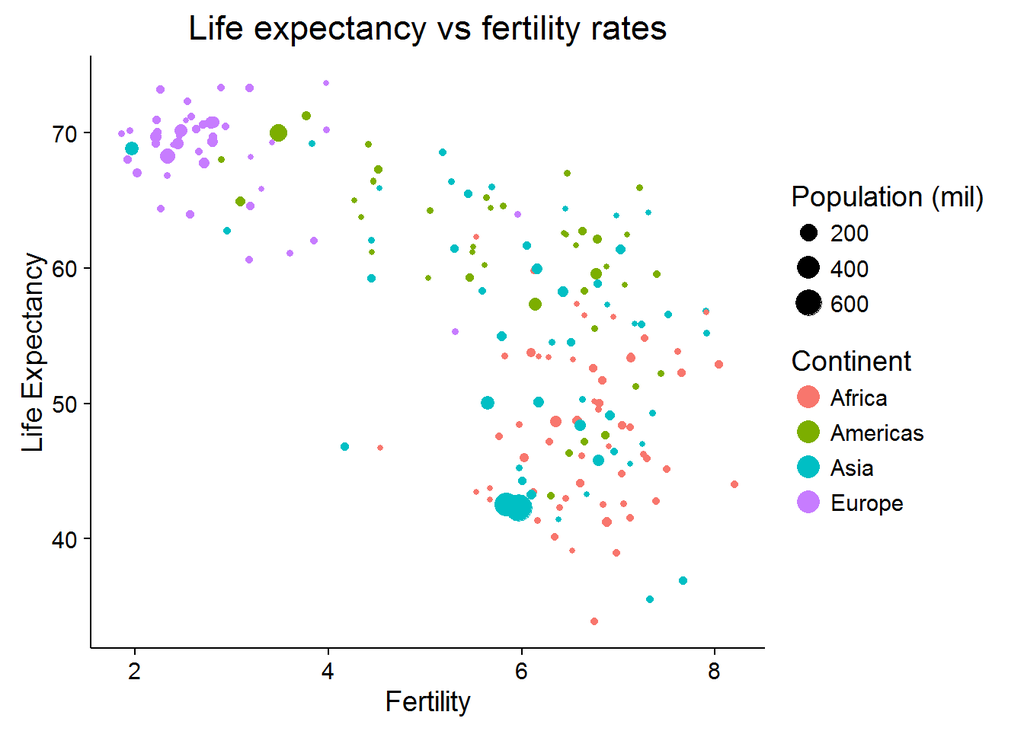

```r
library(ggplot2)

continents <- c("Africa", "Asia", "Europe", "Americas")
years <- 1962
dat <- filter(alldata, year%in%years & continent%in%continents)
p <- ggplot(dat, aes(x=fertility,y=lifeExp)) +  xlab("Fertility") + ylab("Life Expectancy") +  theme_classic(base_size=14) + labs(title="Life expectancy vs fertility rates", colour="Continent", size = "Population (mil)")

p + geom_point(aes(color=continent,size=population/1000000))+ guides(colour = guide_legend(override.aes = list(size=5)))
```

Do you see a dichotomy? Explain.

*There appear to be a negative relationship between life expectancy and fertility. Countries with low fertility rates have higher life expectancy, while those with high fertility rates have lower life expectancy. The relationship is stronger within Americas and Asia, but weaker within countries in Europe and Africa.*

## Problem 3.2

Now we will annotate the plot to show different types of countries.

Learn about OECD and OPEC. Add a couple of columns to your consolidated tables containing a logical vector that tells if a country is OECD and OPEC respectively. It is ok to base membership on 2015.

```r
opec_dat <- "country
        Algeria
        Angola
        Ecuador
        Indonesia
        Iran
        Iraq
        Kuwait
        Libya
        Nigeria
        Qatar
        Saudi Arabia
        United Arab Emirates
        Venezuela
"
opec_dat <- read_csv(opec_dat, trim_ws = TRUE)
oecd_dat <- "country
        Australia
        Austria
        Belgium
        Canada
        Chile
        Czech Republic
        Denmark
        Estonia
        Finland
        France
        Germany
        Greece
        Hungary
        Iceland
        Ireland
        Israel
        Italy
        Japan
        South Korea
        Luxembourg
        Mexico
        Netherlands
        New Zealand
        Norway
        Poland
        Portugal
        Slovak Republic
        Slovenia
        Spain
        Sweden
        Switzerland
        Turkey
        United Kingdom
        United States
"
oecd_dat <- read_csv(oecd_dat, trim_ws = TRUE)

alldata <- mutate(alldata, opec=(country %in% opec_dat$country))
alldata <- mutate(alldata, oecd=(country %in% oecd_dat$country))
```

### Problem 3.3

Make the same plot as in Problem 3.1, but this time use color to annotate the OECD countries and OPEC countries. For countries that are not part of these two organization annotate if they are from Africa, Asia, or the Americas.

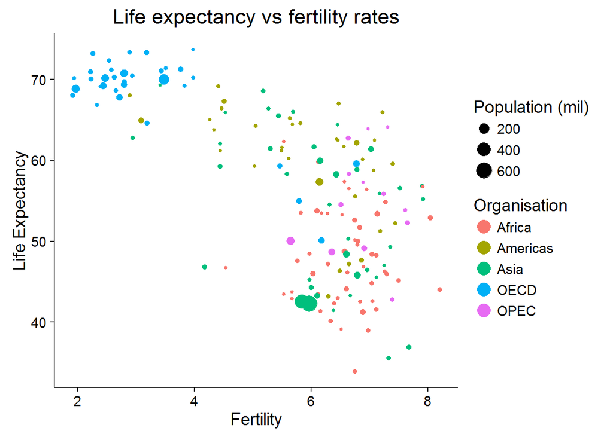

```r
continents <- c("Africa", "Asia", "Americas")
years <- 1962
# Label the countries
alldata <- mutate(alldata, organisation = ifelse(alldata$oecd==TRUE,"OECD",ifelse(alldata$opec==TRUE,"OPEC",alldata$continent)))

dat <- filter(alldata, year%in%years & (continent%in%continents | oecd == TRUE | opec == TRUE))
p <- ggplot(dat, aes(x=fertility,y=lifeExp)) +  xlab("Fertility") + ylab("Life Expectancy") + theme_classic(base_size=14) + labs(title="Life expectancy vs fertility rates", color="Organisation", size = "Population (mil)")
p + geom_point(aes(color=organisation,size=population/1000000)) + guides(color = guide_legend(override.aes = list(size=5)))
```

How would you describe the dichotomy? *OECD countries tend to have low fertily and high life expectancy compared to non-OCED countries. With the exception of the countries in Africa and OPEC, there appear to be a negative relationship between life expectancy and fertility within each continent and organisation. This is apparent in the facet plot below.*

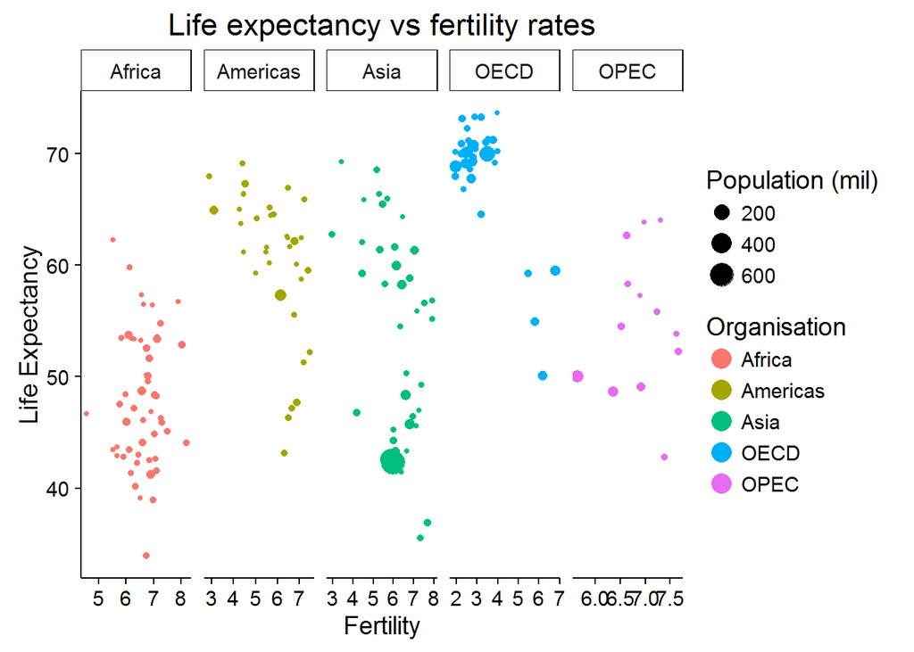

```r
p + geom_point(aes(color=organisation,size=population/1000000)) + guides(colour = guide_legend(override.aes = list(size=5))) +facet_grid(~organisation, scale="free")
```

### Problem 3.4

Explore how this figure changes across time. Show us 4 figures that demonstrate how this figure changes through time.

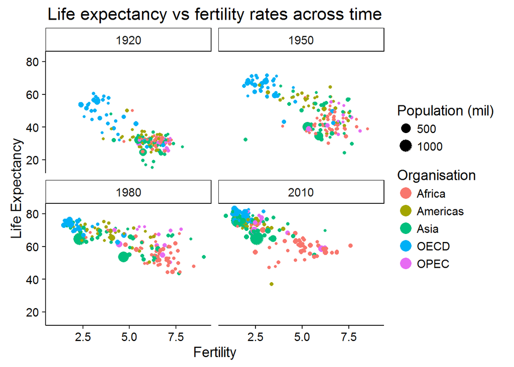

```r
years = c(1920,1950,1980,2010)
dat <- filter(alldata, year%in%years & (continent%in%continents | oecd == TRUE | opec == TRUE))
p <- ggplot(dat, aes(x=fertility,y=lifeExp)) +  xlab("Fertility") + ylab("Life Expectancy") + labs(title="Life expectancy vs fertility rates across time", color="Organisation", size = "Population (mil)") +  theme_classic(base_size=14)

p + geom_point(aes(color=organisation,size=population/1000000))  +
guides(colour = guide_legend(override.aes = list(size=5))) + facet_wrap(~year, scale="fixed")
```

Would you say that the same dichotomy exists today? Explain:

*While the relationship has persisted overtime, it is getting weaker. The slope of the relationship is less steep. Life expectancy for all the countries has moved up the y-axis and with smaller family size. In 1950, over tha half the countries have fertility rates greater than 5, but in 2010 only about a quarter of the countries have fertility rates greater than 5.*

## Problem 3.5 (Optional)

Make an animation with the `gganimate` package.

```r
library(gganimate)

years = seq(from=1950,to=2010,by=5)
p <- filter(alldata, year %in%years & continent%in%continents) %>%
ggplot(aes(x=fertility,y=lifeExp)) +  xlab("Fertility") + ylab("Life Expectancy") + labs(title="Life expectancy vs fertility rates across time", color="Organisation", size = "Population (mil)") +  theme_classic(base_size=14)

p2 <- p + geom_point(aes(color=organisation,size=population/1000000,frame = year))  +
guides(colour = guide_legend(override.aes = list(size=5)))

gg_animate(p2, interval = 0.3)
```

# Problem 4

Having time as a third dimension made it somewhat difficult to see specific country trends. Let’s now focus on specific countries.

## Problem 4.1

Let’s compare France and its former colony Tunisia. Make a plot of fertility versus year with color denoting the country. Do the same for life expecancy. How would you compare Tunisia’s improvement compared to France’s in the past 60 years? Hint: use `geom_line`

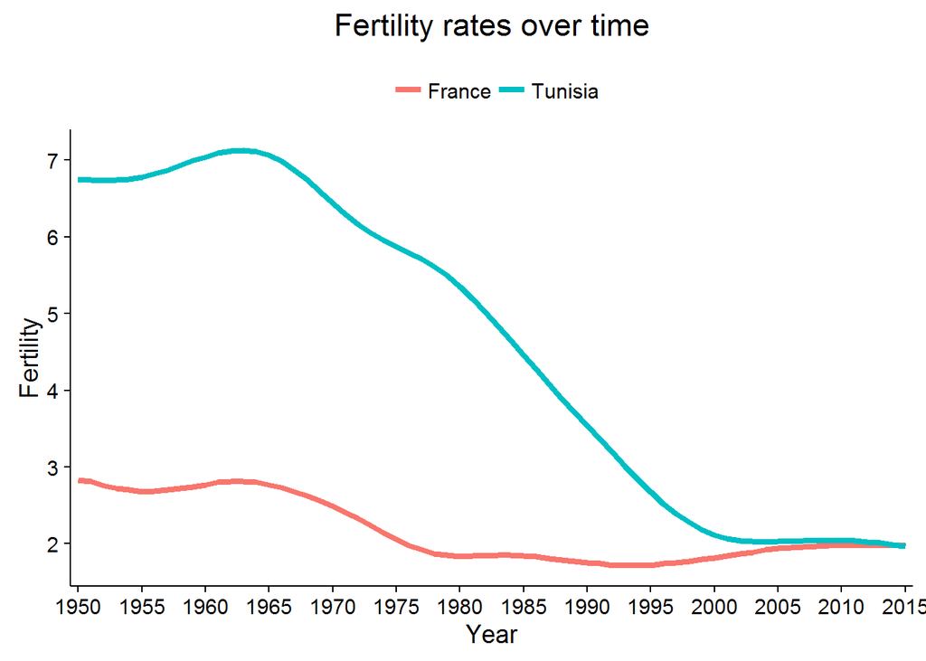

```r
yrFrom <- 1950
yrTo <- 2015

#Plot of Fertility vs year
p <- filter(alldata, country%in%c("France", "Tunisia") & year >= yrFrom) %>% ggplot(aes(x=year,y=fertility, color=country, group=country)) + xlab("Year") + ylab("Fertility") + labs(title="Fertility rates over time", color = "") +  theme_classic(base_size=14)

p + geom_line(size=1.5) + guides(colour = guide_legend(override.aes = list(size=1.5))) + scale_x_discrete(breaks=seq(yrFrom,yrTo,by=5)) + theme(legend.position="top")
```

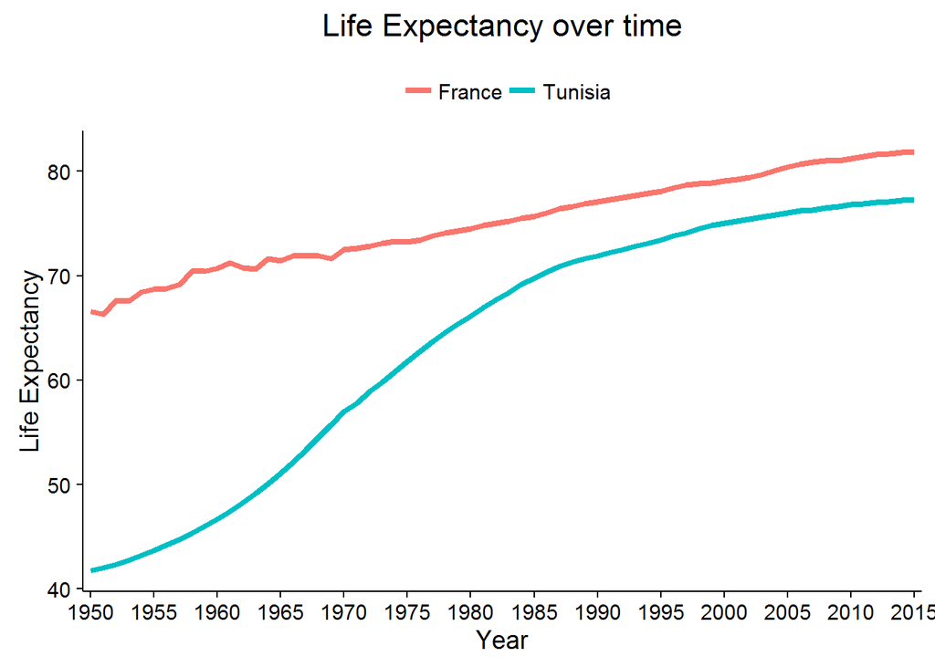

```r
#Plot of Life Expectancy vs year
p <- filter(alldata, country%in%c("France", "Tunisia") & year >= yrFrom) %>%  ggplot(aes(x=year,y=lifeExp, color=country, group=country)) + xlab("Year") + ylab("Life Expectancy") + labs(title="Life Expectancy over time", color = "") +  theme_classic(base_size=14)

p + geom_line(size=1.5) + guides(colour = guide_legend(override.aes = list(size=1.5))) + scale_x_discrete(breaks=seq(yrFrom,yrTo,by=5)) + theme(legend.position="top")
```

*Life expectancy for Tunisia improved dramatically over the last 60 years from 42 years in 1950 to 77 years in 2015. In the 1950, the gap between life expectancy in France and Tunisia is about 25 years, by 2015, the gap has reduced to 5 years. The improvement in life expectancy in Tunisia coincide with a a sharp decrease in fertility rates. Interestingly, while fertility rates fluctuated around 7 between 1950 and 1965, life expectancy improved.*

*In contrast, life expectancy in France increased gradually over the same period even though fertility rates has stablised around 2 since 1980.*

## Problem 4.2

Do the same, but this time compare Vietnam to the OECD countries.

*We compare Vietnam to the ‘median’ country in the OECD*

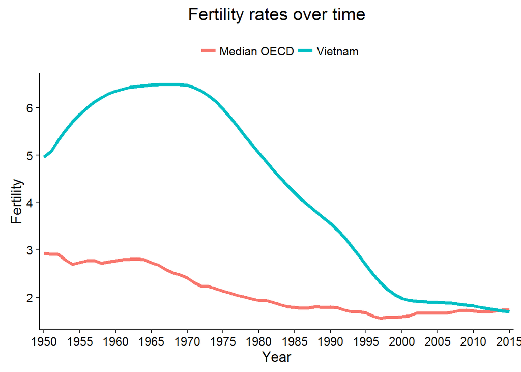

```r
# Filter data Vietnam and OECD
sumDat <- filter(alldata, (country=="Vietnam" | oecd == TRUE) & year >= yrFrom) %>%
# Create new variable indicating "OECD" if oecd country, otherwise name of the country
mutate(group = ifelse(oecd==TRUE,"Median OECD",country)) %>%
# Then summarise the data by the variable
          group_by(group, year) %>%
          summarise("avg_fertility" = median(fertility),
                  "avg_lifeExp" = median(lifeExp))

p <- ggplot(sumDat, aes(x=year,y=avg_fertility, color=group, group=group)) + xlab("Year") + ylab("Fertility") + labs(title="Fertility rates over time", color = "") +  theme_classic(base_size=14)

p + geom_line(size=1.5) + guides(colour = guide_legend(override.aes = list(size=1.5))) + scale_x_discrete(breaks=seq(yrFrom,yrTo,by=5)) + theme(legend.position="top")
```

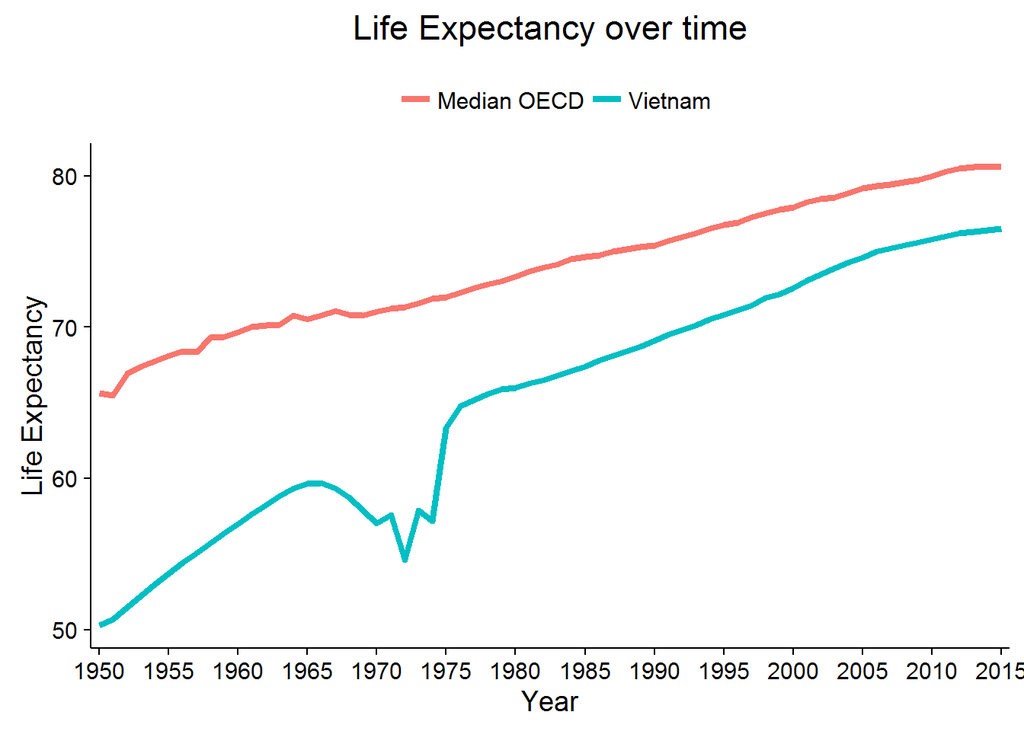

```r
#Plot of Life Expectancy vs year
p <- ggplot(sumDat, aes(x=year,y=avg_lifeExp, color=group, group=group)) + xlab("Year") + ylab("Life Expectancy") + labs(title="Life Expectancy over time", color = "") +  theme_classic(base_size=14)

p + geom_line(size=1.5) + guides(colour = guide_legend(override.aes = list(size=1.5))) + scale_x_discrete(breaks=seq(yrFrom,yrTo,by=5)) + theme(legend.position="top")
```

*Life expectancy for Vietnam improved dramatically over the last 60 years from 50 years in 1950 to 77 years in 2015. In the 1950, the gap between life expectancy in Vietnam and OECD countries is about 15 years, by 2015 the gap has reduced to 4 years. Between 1950 and 1965 when fertility rates increased, life expectancy also increased. There was a dip in life expectancy between 1965 and 1975 due to the Vietnam war.*

*Since 2010, fertility rate in Vietnam is similar to the median fertility rate in OECD countries but the life expectancy is still below the OECD.*

*The two specific examples suggests that the improvement in life expectancy is due to other factors such as the wealth of the countries.*

# Problem 5

We are now going to examine GDP per capita per day.

## Problem 5.1

Create a smooth density estimate of the distribution of GDP per capita per day across countries in 1970. Include OECD, OPEC, Asia, Africa, and the Americas in the computation. When doing this we want to weigh countries with larger populations more. We can do this using the “weight”" argument in `geom_density`.

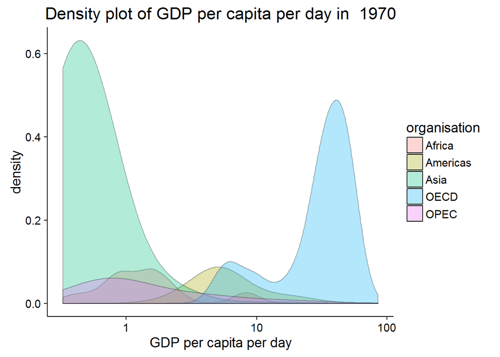

```r
density_plot <- function(dat, years){
    p <- filter(dat, year%in%years) %>%
      ggplot(aes(x=gdp/population/365,fill = organisation, weight=population/sum(population))) +
      xlab("GDP per capita per day") + labs(title=paste("Density plot of GDP per capita per day in ", years)) +
      theme_classic(base_size=14)
  return (p)
}

dat <- filter(alldata, organisation%in%c("OECD", "OPEC", "Asia", "Africa", "Americas") & population != 0)
p <- density_plot(dat, 1970)
p + geom_density(alpha=.3) + scale_x_log10()
```

## Problem 5.2

Now do the same but show each of the five groups separately.

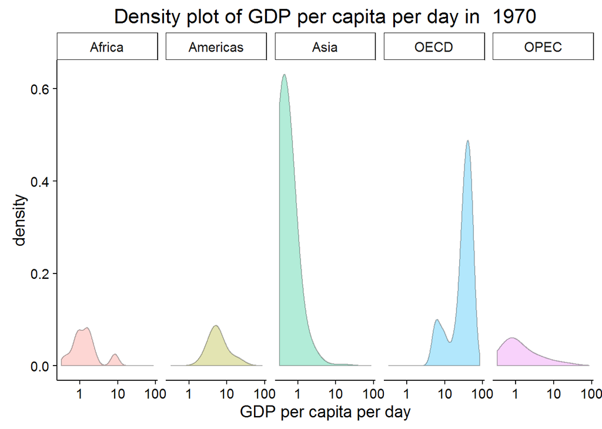

```r
p + facet_grid(~organisation) + geom_density(alpha=.3)+ scale_x_log10() + theme(legend.position = "none")
```

## Problem 5.3

Visualize these densities for several years. Show a couple of of them. Summarize how the distribution has changed through the years.

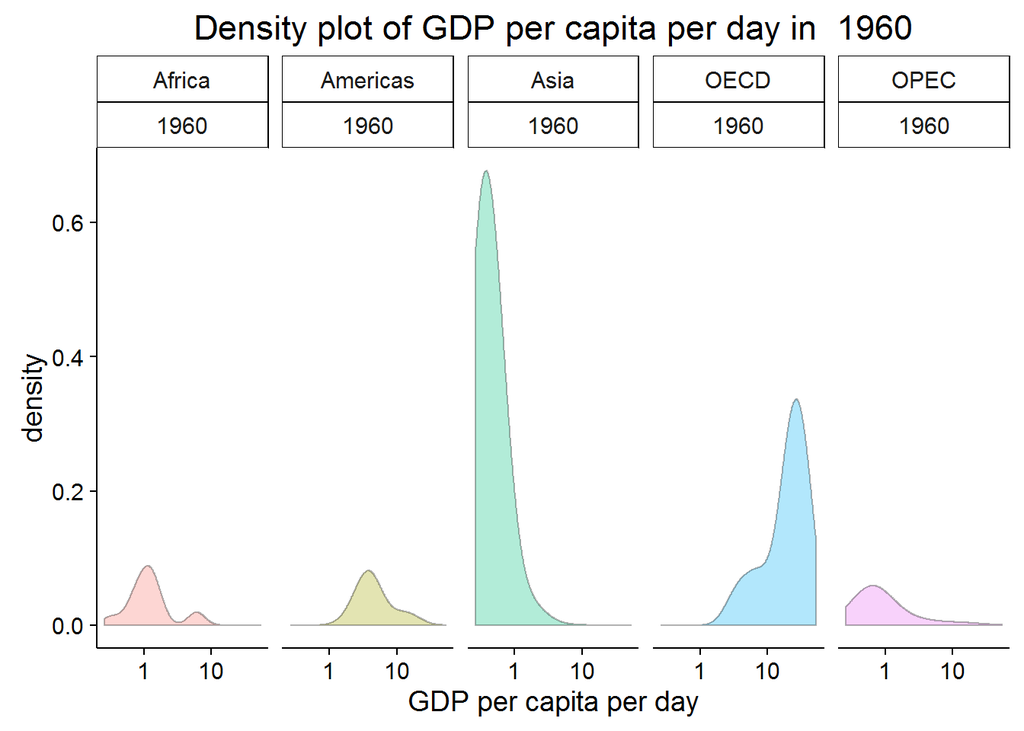

```r
density_plot(dat, 1960) + facet_grid(~organisation+year) + geom_density(alpha=.3) + scale_x_log10()  + theme(legend.position = "none")
```

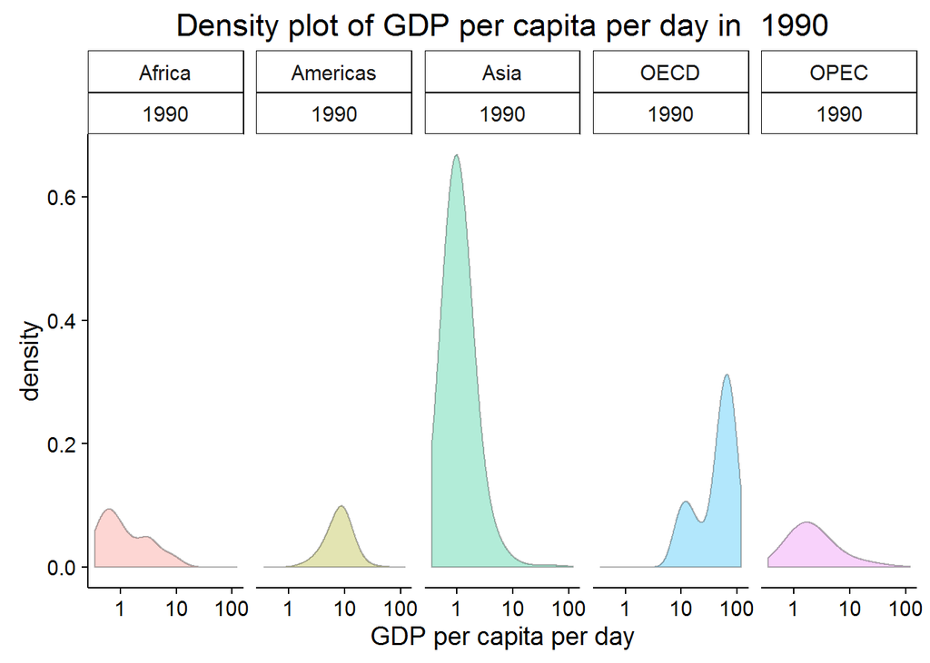

```r
density_plot(dat, 1990) + facet_grid(~organisation+year) + geom_density(alpha=.3) + scale_x_log10()  + theme(legend.position = "none")
```

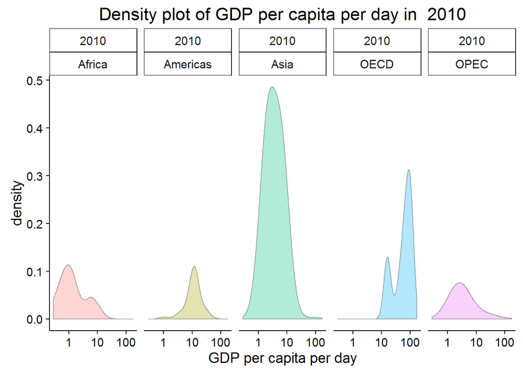

```r
density_plot(dat, 2010) + facet_grid(~year+organisation) + geom_density(alpha=.3) + scale_x_log10()  + theme(legend.position = "none")
```

*The GDP per capita per day has increased over time with more countries shifting to the right of the x-axis In 1970, the distribution of GDP per capita amongst the countries in Asia and OPEC were highly skewed to the right. By 2010, the density distribution is resembles more of a normal distribution.*